# Fairness: fairness affects profits

Jose Giner

Andrés Calandín

## Exercise 1 (already implemented):

Prepare the database. From the files transrisk_performance_by_race_ssa.csv, transrisk_cdf_by_race_ssa.csv and totals.csv calculate (for each race):

1. - The true possives per Score.
2. - The true positives per Score relative to the total.
3. - The accumulated of true positives relative per score.
4. - The same (1, 2 and 3) for the false positives.
5. - The relative profits per score.
6. - The total profits per score.
7. - The accumuated relative profits per score (using values computed in step 5).
8. - The accumulated profits per score (using totals computed in step 6).

```r
library(dplyr)
library(reshape2)
library(spatstat.utils)
library(ggplot2)


setwd("C:\\Users\\Jose Giner\\OneDrive\\Escritorio\\EDM\\Practica 1 Sin sol")

performance <- read.csv("transrisk_performance_by_race_ssa.csv")
cdf <- read.csv("transrisk_cdf_by_race_ssa.csv")
total <- read.csv("totals.csv")
names(performance)[2] <- "White"
names(total)[2] <- "White"
names(cdf)[2] <- "White"

cutoff <- 5.0/6.0 #Asumimos que dar el préstamo y no pargarlo es 5 veces más costoso que darle el prestamo y que lo pague
performance[,2:5] <- (100 - performance[,2:5])/100
cdf[,2:5] <- cdf[,2:5]/100

df <- diff(cdf$White)
cdf$sWhite <- c(cdf$White[1], df)
df <- diff(cdf$Black)
cdf$sBlack <- c(cdf$Black[1], df)
df <- diff(cdf$Hispanic)
cdf$sHispanic <- c(cdf$Hispanic[1], df)
df <- diff(cdf$Asian)
cdf$sAsian <- c(cdf$Asian[1], df)

cdf$TPWhite <- performance$White * cdf$sWhite
cdf$TPWhite <- cdf$TPWhite / sum(cdf$TPWhite)
cdf$FPWhite <- (1-performance$White) * cdf$sWhite
cdf$FPWhite <- cdf$FPWhite /sum(cdf$FPWhite)
cdf$TPcWhite <- revcumsum(cdf$TPWhite)
cdf$FPcWhite <- revcumsum(cdf$FPWhite)
cdf$TPBlack <- performance$Black * cdf$sBlack
cdf$TPBlack <- cdf$TPBlack / sum(cdf$TPBlack)
cdf$FPBlack <- (1-performance$Black) * cdf$sBlack
cdf$FPBlack <- cdf$FPBlack /sum(cdf$FPBlack)
cdf$TPcBlack <- revcumsum(cdf$TPBlack)
cdf$FPcBlack <- revcumsum(cdf$FPBlack)
cdf$TPHispanic <- performance$Hispanic * cdf$sHispanic
cdf$TPHispanic <- cdf$TPHispanic / sum(cdf$TPHispanic)
cdf$FPHispanic <- (1-performance$Hispanic) * cdf$sHispanic
cdf$FPHispanic <- cdf$FPHispanic /sum(cdf$FPHispanic)
cdf$TPcHispanic <- revcumsum(cdf$TPHispanic)
cdf$FPcHispanic <- revcumsum(cdf$FPHispanic)
cdf$TPAsian <- performance$Asian * cdf$sAsian
cdf$TPAsian <- cdf$TPAsian / sum(cdf$TPAsian)
cdf$FPAsian <- (1-performance$Asian) * cdf$sAsian
cdf$FPAsian <- cdf$FPAsian /sum(cdf$FPAsian)
cdf$TPcAsian <- revcumsum(cdf$TPAsian)
cdf$FPcAsian <- revcumsum(cdf$FPAsian)

performance$pWhite <- performance$White - cutoff
performance$pBlack <- performance$Black - cutoff
performance$pHispanic <- performance$Hispanic - cutoff
performance$pAsian <- performance$Asian - cutoff

performance$ptWhite <- performance$pWhite * cdf$sWhite * total$White
performance$ptBlack <- performance$pBlack  * cdf$sBlack * total$Black
performance$ptHispanic <- performance$pHispanic  * cdf$sHispanic * total$Hispanic
performance$ptAsian <- performance$pAsian  * cdf$sAsian * total$Asian

performance$ptcWhite <- revcumsum(performance$ptWhite)
performance$ptcBlack <- revcumsum(performance$ptBlack)
performance$ptcHispanic <- revcumsum(performance$ptHispanic)
performance$ptcAsian <- revcumsum(performance$ptAsian)

performance$pcWhite <- revcumsum(performance$pWhite)
performance$pcBlack <- revcumsum(performance$pBlack)
performance$pcHispanic <- revcumsum(performance$pHispanic)
performance$pcAsian <- revcumsum(performance$pAsian)
```

## Exercise 2: Distribution of the samples.

Build a barplot with the score distribution by ethnicity.

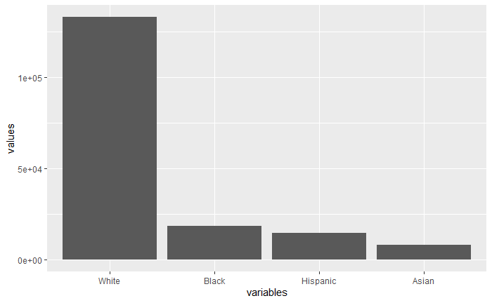

```r
variables = colnames(total)[2:5]
values = as.numeric(total[1,2:5])
total2 = data.frame(variables, values)

ggplot(total2, aes(x= variables, y = values)) +
  geom_bar(stat = "identity") + scale_x_discrete(limits = variables)
```

## Exercise 3: Draw 3 plots:

1. - One that shows the absolute profits by race depending on the score threshold
2. - A second one that shows the relative profits by race depending on the score threshold
3. - The third one the ROC curve of each race (the four curves in the same plot)

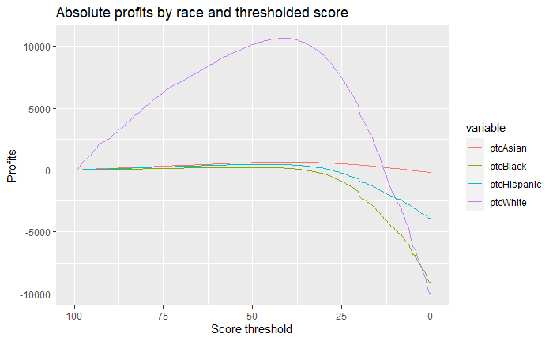

```r
library(tidyr)
p1 = performance %>%
    gather(variable,value, ptcWhite, ptcBlack, ptcHispanic, ptcAsian)

p1 %>%
  ggplot(aes(x= Score, y=value, colour=variable)) +  scale_x_reverse() +
      geom_line() + ggtitle("Absolute profits by race and thresholded score") + xlab("Score threshold") + ylab("Profits")
```

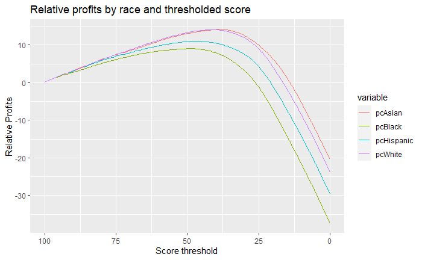

```r
p2 = performance %>%
  gather(variable,value, pcWhite, pcBlack, pcHispanic, pcAsian)

p2 %>%
    ggplot(aes(x= Score, y=value, colour=variable)) +  scale_x_reverse() +
    geom_line() + ggtitle("Relative profits by race and thresholded score") + xlab("Score threshold") + ylab("Relative Profits")
```

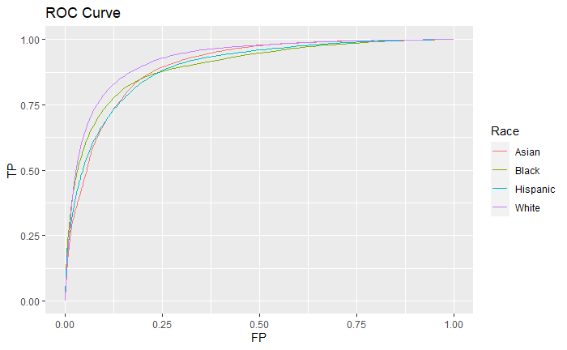

```r
cdf1 = cdf %>%
   gather(variable1, val1, TPcWhite, TPcBlack, TPcHispanic, TPcAsian)

cdf2 = cdf %>% gather(variable2, val2, FPcWhite, FPcBlack, FPcHispanic, FPcAsian)
cdf3 = cdf %>% gather(Race, val3, White, Black, Hispanic, Asian)
cdf4 = cbind(cdf1,cdf2[,23])
cdf4 = cbind(cdf4,cdf3[,22])
colnames(cdf4)[24:25] = c('val2','Race')


cdf4 %>%
    ggplot() +
    geom_line(aes(x=val2, y= val1, color = Race)) + ggtitle("ROC Curve") + xlab("FP") + ylab("TP")
```

```r
NA
NA
```

**QUESTION:** **Can you see strong dependencies on the race group? Make zoom at the maximum curvature point. What can you see there?**

From the absolute profits by race graph, when white´s profit starts to fall, we can appreciate that other racial´s groups profits also start to decrease more or less at the same threshold score value as a consecuence, so there could be a dependence. In the relative profits by race graph, the evolution is the same for all groups but the maximun curvature point differs, and it is the Black race that reaches before to this point as well as being the lowest one. In the ROC curves the same thing happens, where all groups seem to have similar area under the curve.

## Exercise 4: MAXIMUM PROFIT:

Pick group-dependent score thresholds in a way that maximizes profit. Compute this value and show it in the three plots built in the previous exercise Compute the resulting profits of this decision.

```r
c = 1
TotprofitMax = 0
listaScores = c()

for (P.raza in performance[,14:17]){
  c = c + 1
  scoreMax = performance$Score[which.max(P.raza)]
  print(paste0(colnames(performance)[c]," score: ",scoreMax ))
  listaScores = c(listaScores,scoreMax)

  TotprofitMax = TotprofitMax + max(P.raza)
}
```

```
[1] "White score: 41"
[1] "Black score: 49"
[1] "Hispanic score: 47"
[1] "Asian score: 38.5"
```

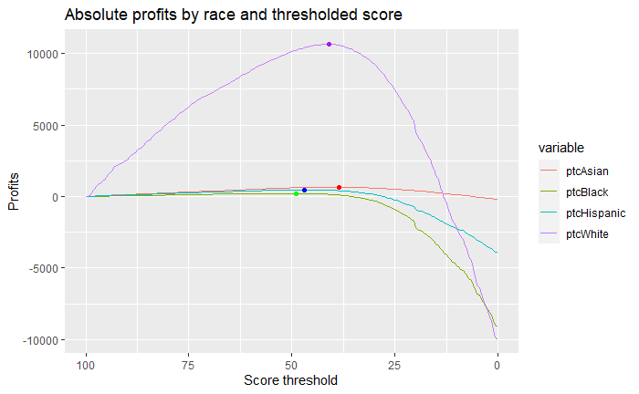

```r
p1  %>%

      ggplot(aes(x= Score, y=value, color=variable)) +  scale_x_reverse() +
      geom_line() + geom_point(aes(x= Score[which.max(performance$ptcAsian)],y = max(performance$ptcAsian)), color = "red") +
      geom_point(aes(x= Score[which.max(performance$ptcBlack)],y = max(performance$ptcBlack)),color = "green") +
      geom_point(aes(x= Score[which.max(performance$ptcHispanic)],y = max(performance$ptcHispanic)), color = "blue") +
      geom_point(aes(x= Score[which.max(performance$ptcWhite)],y = max(performance$ptcWhite)), color = "purple") + ggtitle("Absolute profits by race and thresholded score") + xlab("Score threshold") + ylab("Profits")
```

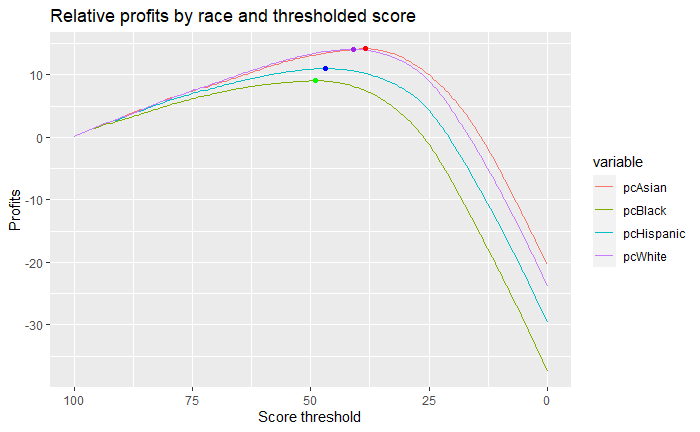

```r
p2%>%

      ggplot(aes(x= Score, y=value, color=variable)) +  scale_x_reverse() +
      geom_line() + geom_point(aes(x= Score[which.max(performance$pcAsian)],y = max(performance$pcAsian)), color = "red") +
      geom_point(aes(x= Score[which.max(performance$pcBlack)],y = max(performance$pcBlack)), color = "green") +
      geom_point(aes(x= Score[which.max(performance$pcHispanic)],y = max(performance$pcHispanic)) , color = "blue") +
      geom_point(aes(x= Score[which.max(performance$pcWhite)],y = max(performance$pcWhite)), color = "purple") + ggtitle("Relative profits by race and thresholded score") + xlab("Score threshold") + ylab("Profits")
```

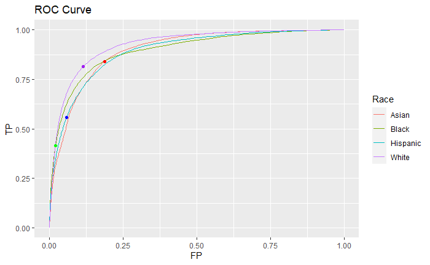

```r
cdf4 %>%
    ggplot() +
    geom_line(aes(x=val2, y= val1, color = Race)) + ggtitle("ROC Curve") + xlab("FP") + ylab("TP") +
    geom_point(aes(x = cdf$FPcAsian[which(cdf$Score == listaScores[4])], y = cdf$TPcAsian[which(cdf$Score == listaScores[4])]), color = "red") +
    geom_point(aes(x = cdf$FPcBlack[which(cdf$Score == listaScores[2])], y = cdf$TPcBlack[which(cdf$Score == listaScores[2])]), color = "green") +
    geom_point(aes(x = cdf$FPcHispanic[which(cdf$Score == listaScores[3])], y = cdf$TPcHispanic[which(cdf$Score == listaScores[3])]), color = "blue") +
    geom_point(aes(x = cdf$FPcWhite[which(cdf$Score == listaScores[1])], y = cdf$TPcWhite[which(cdf$Score == listaScores[1])]), color = "purple")
```

```r
NA
NA
```

## Exercise 5: SINGLE THRESHOLD:

Pick a single uniform score threshold for all groups in a way that maximizes profit. Compute this value and show it in the three plots built in the exercise 2. Compute the resulting profits of this decission.

```r
profitsByScore = data.frame(Score = numeric(), Profit = numeric())

for (i in rownames(performance)){
  scorePr = 0
  for (j in 14:17){
    scorePr = scorePr + performance[i,j]

  }


  df3 = data.frame(Score = performance[i,1], Profit = scorePr)
  profitsByScore = rbind(profitsByScore, df3 )

}

ind_score = which.max(profitsByScore$Profit)
scoreMax = profitsByScore$Score[ind_score]
for (j in 2:5){
  print(paste0(colnames(performance)[j]," score: ",scoreMax ))
}
```

```
[1] "White score: 42.5"
[1] "Black score: 42.5"
[1] "Hispanic score: 42.5"
[1] "Asian score: 42.5"
```

```r
profitMaxSingle = max(profitsByScore$Profit)
```

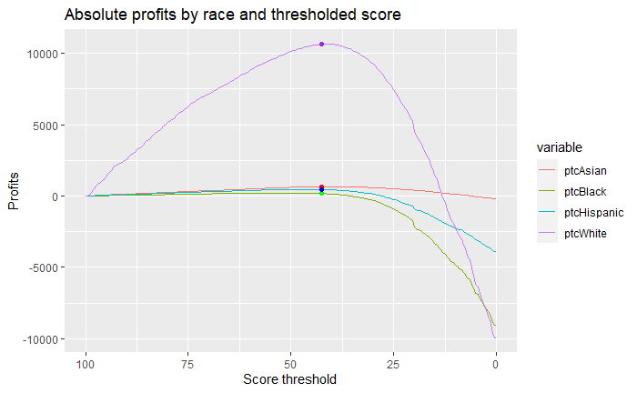

```r
p1%>%

      ggplot(aes(x= Score, y=value, color=variable)) +  scale_x_reverse() +
      geom_line() + geom_point(aes(scoreMax , y = performance$ptcAsian[ind_score]), color = "red") +
      geom_point(aes(x= scoreMax , y = performance$ptcBlack[ind_score]), color = "green") +
      geom_point(aes(x= scoreMax , y = performance$ptcHispanic[ind_score]), color = "blue") +
      geom_point(aes(x= scoreMax , y = performance$ptcWhite[ind_score]), color = "purple") + ggtitle("Absolute profits by race and thresholded score") + xlab("Score threshold") + ylab("Profits")
```

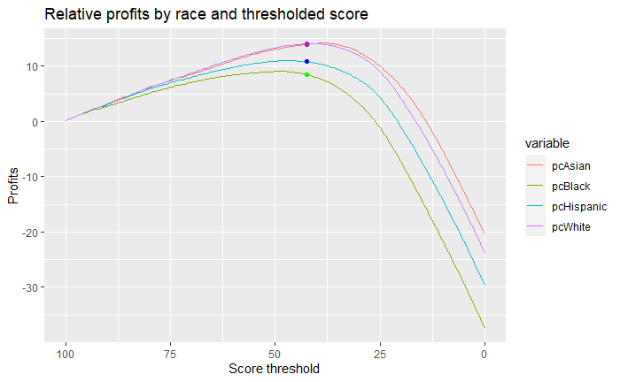

```r
p2  %>%

      ggplot(aes(x= Score, y=value, color=variable)) +  scale_x_reverse() +
      geom_line() + geom_point(aes(x= scoreMax,y = performance$pcAsian[ind_score]), color = "red") +
      geom_point(aes(x = scoreMax,y = performance$pcBlack[ind_score]), color = "green") +
      geom_point(aes(x= scoreMax ,y = performance$pcHispanic[ind_score]), color = "blue") +
      geom_point(aes(x= scoreMax ,y = performance$pcWhite[ind_score]), color = "purple") + ggtitle("Relative profits by race and thresholded score") + xlab("Score threshold") + ylab("Profits")
```

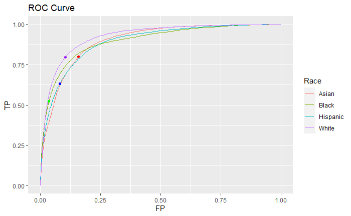

```r
cdf4 %>%
  ggplot() +
    geom_line(aes(x=val2, y= val1, color = Race)) + ggtitle("ROC Curve") + xlab("FP") + ylab("TP") +
    geom_point(aes(x = cdf$FPcAsian[ind_score], y = cdf$TPcAsian[ind_score]), color = "red") +
    geom_point(aes(x = cdf$FPcBlack[ind_score], y = cdf$TPcBlack[ind_score]), color = "green") +
    geom_point(aes(x = cdf$FPcHispanic[ind_score], y = cdf$TPcHispanic[ind_score]), color = "blue") +
    geom_point(aes(x = cdf$FPcWhite[ind_score], y = cdf$TPcWhite[ind_score]), color = "purple")
```

## Exercise 6: SEPARATION (partially implemented):

Achieve an equal true/false positive rate in all groups. Subject to this constraint, maximize profit. Compute this value and show it in the ROC curve built in the exercise 2 (in the other has no sense…. Why?) Compute the resulting profits of this decission.

```r
rsAsian <- approx(cdf$FPcAsian, cdf$TPcAsian, method = "linear", n=1001)
```

```
collapsing to unique 'x' values
```

```r
rsAsian <- as.data.frame(rsAsian)
rsWhite <- approx(cdf$FPcWhite, cdf$TPcWhite, method = "linear", n=1001)
rsWhite <- as.data.frame(rsWhite)
rsBlack <- approx(cdf$FPcBlack, cdf$TPcBlack, method = "linear", n=1001)
rsBlack <- as.data.frame(rsBlack)
rsHispanic <- approx(cdf$FPcHispanic, cdf$TPcHispanic, method = "linear", n=1001)
rsHispanic <- as.data.frame(rsHispanic)

r <- cbind(rsWhite$y, rsBlack$y, rsHispanic$y, rsAsian$y)
r<- as.data.frame(r)
wm <- apply(r, 1, FUN = which.min)

r$x = 0
r$y = 0
r$profit = 0
for(i in 1:length(wm)){
   r$x[i] <- ifelse(wm[i] == 1, rsWhite$x[i], ifelse(wm[i] == 2, rsBlack$x[i], ifelse(wm[i] == 3, rsHispanic$x[i], rsAsian$x[i])))
   r$y[i] <- ifelse(wm[i] == 1, rsWhite$y[i], ifelse(wm[i] == 2, rsBlack$y[i], ifelse(wm[i] == 3, rsHispanic$y[i], rsAsian$y[i])))

   if(wm[i] == 1){
     index <- which.min(abs(cdf$TPcWhite - rsWhite$y[i]))
     r$profit[i] <- performance$pcWhite[index]
   }
   if(wm[i] == 2){
     index <- which.min(abs(cdf$TPcBlack - rsBlack$y[i]))
     r$profit[i] <- performance$pcBlack[index]
   }
   if(wm[i] == 3){
     index <- which.min(abs(cdf$TPcHispanic - rsHispanic$y[i]))
     r$profit[i] <- performance$pcHispanic[index]
   }
   if(wm[i] == 4){
     index <- which.min(abs(cdf$TPcAsian - rsAsian$y[i]))
     r$profit[i] <- performance$pcAsian[index]
   }
}

indexl <- which.max(r$profit)
if(wm[indexl] == 1){
  index <- which.min(abs(performance$pcWhite - r$profit[indexl]))
  pROC <- c(cdf$FPcWhite[index], cdf$TPcWhite[index])
  profit <- performance$pcWhite[index]
}
if(wm[indexl] == 2){
  index <- which.min(abs(performance$pcBlack - r$profit[indexl]))
  pROC <- c(cdf$FPcBlack[index], cdf$TPcBlack[index])
  profit <- performance$pcBlack[index]
}
if(wm[indexl] == 3){
  index <- which.min(abs(performance$pcHispanic - r$profit[indexl]))
  pROC <- c(cdf$FPcHispanic[index], cdf$TPcHispanic[index])
  profit <- performance$pcHispanic[index]
}
if(wm[indexl] == 4){
  index <- which.min(abs(performance$pcAsian - r$profit[indexl]))
  pROC <- c(cdf$FPcAsian[index], cdf$TPcAsian[index])
  profit <- performance$pcAsian[index]
}

Score <- cdf$Score[index]

if(wm[indexl] == 1){
  TP = cdf$TPcWhite[which(cdf$Score == Score)]
  FP = cdf$FPcWhite[which(cdf$Score == Score)]
}
if(wm[indexl] == 2){
  TP = cdf$TPcBlack[which(cdf$Score == Score)]
  FP = cdf$FPcBlack[which(cdf$Score == Score)]

}
if(wm[indexl] == 3){
  TP = cdf$TPcHispanic[which(cdf$Score == Score)]
  FP = cdf$FPcHispanic[which(cdf$Score == Score)]
}
if(wm[indexl] == 4){
  TP = cdf$TPcAsian[which(cdf$Score == Score)]
  FP = cdf$FPcAsian[which(cdf$Score == Score)]
}

profWhite = profit * cdf$sWhite[index] * total$White
profBlack = profit * cdf$sBlack[index] * total$Black
profHispanic = profit * cdf$sHispanic[index] * total$Hispanic
profAsian = profit * cdf$sAsian[index] * total$Asian
profTotal = profWhite + profBlack + profHispanic + profAsian


#Dibuja EL PUNTO sobre la curva ROC. Recuerda calcular el beneficio
```

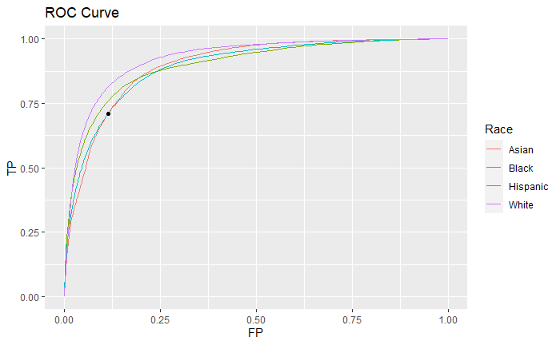

```r
cdf4 %>%
  ggplot() +
    geom_line(aes(x=val2, y= val1, color = Race)) + ggtitle("ROC Curve") + xlab("FP") + ylab("TP") +
    geom_point(aes(x = FP, y = TP))
```

```r
NA
NA
NA
```

## Exercise 7: INDEPENCENCE (partially implemented):

Achieve an equal acceptance rate in all groups. Subject to this constraint, maximize profit. Compute this value and show it in the three plots built in the exercise 2 Compute the resulting profits of this decission.

```r
cWhite <- 1
cBlack <- 1
cHispanic <- 1
cAsian <- 1
cont <- 1
ar <- 0
best_profit <- 0
actual_profit <- 0
Best_White <- 1
Best_Black <- 1
Best_Hispanic <- 1
Best_Asian <- 1

p <- select(cdf, White, Black, Hispanic, Asian)
pm <- melt(p)
```

[output not shown]

```r
pm <- pm[order(pm$value),]

maxcont <- 4 * nrow(cdf)
actual_profit <- performance$ptcWhite[cWhite] + performance$ptcBlack[cBlack] + performance$ptcHispanic[cHispanic] + performance$ptcAsian[cAsian]
best_profit <- actual_profit
while(cont <= maxcont)
{
  ar <- pm$value[cont]
  if(cdf$White[cWhite] < ar)
  {
    cWhite <- cWhite + 1
  }
  if(cdf$Black[cBlack] < ar)
  {
    cBlack <- cBlack + 1
  }
  if(cdf$Hispanic[cHispanic] < ar)
  {
    cHispanic <- cHispanic+ 1
  }
  if(cdf$Asian[cAsian] < ar)
  {
    cAsian <- cAsian + 1
  }

  actual_profit <- performance$ptcWhite[cWhite] + performance$ptcBlack[cBlack] + performance$ptcHispanic[cHispanic] + performance$ptcAsian[cAsian]
  if(actual_profit > best_profit)
  {
    best_profit <- actual_profit
    Best_White <- cWhite
    Best_Black <- cBlack
    Best_Hispanic <- cHispanic
    Best_Asian <- cAsian
  }

  cont <- cont +1
}
MP_index = data.frame(White = 0, Black = 0, Hispanic = 0, Asian = 0)

MP_index$White <- Best_White
MP_index$Black <- Best_Black
MP_index$Hispanic <- Best_Hispanic
MP_index$Asian <- Best_Asian

MP_index
```

| White | Black | Hispanic | Asian |
| --- | --- | --- | --- |
| 117 | 42 | 73 | 117 |

```r
print(paste("White score: ",performance$Score[MP_index[1,1]]))
```

```
[1] "White score:  58"
```

```r
print(paste("Black score: ",performance$Score[MP_index[1,2]]))
```

```
[1] "Black score:  20.5"
```

```r
print(paste("Hispanic score: ",performance$Score[MP_index[1,3]]))
```

```
[1] "Hispanic score:  36"
```

```r
print(paste("Asian score: ",performance$Score[MP_index[1,4]]))
```

```
[1] "Asian score:  58"
```

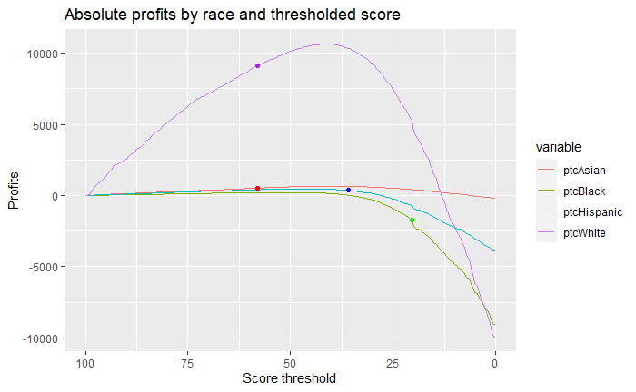

```r
g1 = p1  %>%

      ggplot(aes(x= Score, y=value, color=variable)) +  scale_x_reverse() +
      geom_line() + ggtitle("Absolute profits by race and thresholded score")  + xlab("Score threshold") + ylab("Profits")

g1 + geom_point(aes(x=performance$Score[MP_index$White], y=performance$ptcWhite[MP_index$White]), color = "purple") +
  geom_point(aes(x=performance$Score[MP_index$Black], y=performance$ptcBlack[MP_index$Black]), color = "green") +
  geom_point(aes(x=performance$Score[MP_index$Hispanic], y=performance$ptcHispanic[MP_index$Hispanic]), color = "blue") +
  geom_point(aes(x=performance$Score[MP_index$Asian], y=performance$ptcAsian[MP_index$Asian]), color = "red")
```

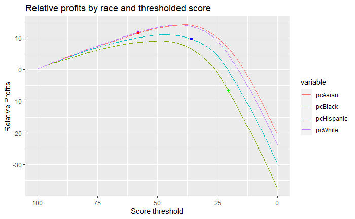

```r
g2 = p2 %>%
    ggplot(aes(x= Score, y=value, colour=variable)) +  scale_x_reverse() +
    geom_line() + ggtitle("Relative profits by race and thresholded score") + xlab("Score threshold") + ylab("Relative Profits")


g2 + geom_point(aes(x=performance$Score[MP_index$White], y=performance$pcWhite[MP_index$White]), color = "purple") +
  geom_point(aes(x=performance$Score[MP_index$Black], y=performance$pcBlack[MP_index$Black]), color = "green") +
  geom_point(aes(x=performance$Score[MP_index$Hispanic], y=performance$pcHispanic[MP_index$Hispanic]), color = "blue") +
  geom_point(aes(x=performance$Score[MP_index$Asian], y=performance$pcAsian[MP_index$Asian]), color = "red")
```

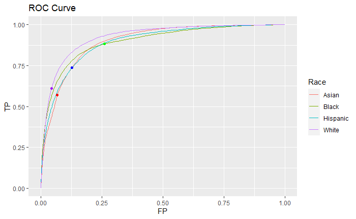

```r
gROC = cdf4 %>%
      ggplot() +
      geom_line(aes(x=val2, y= val1, color = Race)) + ggtitle("ROC Curve") + xlab("FP") + ylab("TP")

gROC + geom_point(aes(x=cdf$FPcWhite[MP_index$White], y=cdf$TPcWhite[MP_index$White]), color = "purple") +
  geom_point(aes(x=cdf$FPcBlack[MP_index$Black], y=cdf$TPcBlack[MP_index$Black]), color = "green") +
  geom_point(aes(x=cdf$FPcHispanic[MP_index$Hispanic], y=cdf$TPcHispanic[MP_index$Hispanic]), color = "blue") +
  geom_point(aes(x=cdf$FPcAsian[MP_index$Asian], y=cdf$TPcAsian[MP_index$Asian]), color = "red")
```

```r
IND_Profit <- best_profit
```

## Exercise 8:

Show the different profits obtained using the 4 “fairness” criteria implemented: Maximum profit, single threshold, separation and independence

```r
print(paste0('Profit if we use Maximum Profit criteria: ',TotprofitMax))
```

```
[1] "Profit if we use Maximum Profit criteria: 11968.57458893"
```

```r
print(paste0('Profit if we use Single Threshold criteria: ',profitMaxSingle))
```

```
[1] "Profit if we use Single Threshold criteria: 11888.1095257133"
```

```r
print(paste0('Profit if we use Separation criteria: ', profTotal))
```

```
[1] "Profit if we use Separation criteria: 10350.8117286566"
```

```r
print(paste0('Profit if we use Independence criteria: ', IND_Profit))
```

```
[1] "Profit if we use Independence criteria: 8253.01749189"
```

**QUESTIONS:** **Why has only sense to show the Separation criteria in the ROC plot?** It is necessary to represent this criteria in a ROC space because intersection points from ROC curves determine this optimal thresholded score that minimizes cost.

**Does the criterion of fairness really affect the bank’s profits?** It affects the bank’s profits because we can see that depending on the thresholded score, the profits obtained will differ, where some groups could benefit more than others. The Maximum Profit criteria produces the most and maximum totalized profit and the Independence criteria the least one.